# Assigment 2 - Predictive Modeling

This project focuses on predicting the variable “Sales” and understanding its relationship with the available features, with special emphasis on investment-related variables. The main objective is to not only build an accurate predictive model but also to provide clear explanations and insights into the factors influencing sales performance.

To achieve this, advanced machine learning methodologies and feature engineering techniques will be applied, following the guidelines provided in the course. Particular attention will be given to the interpretability of the models, ensuring that the results are actionable and aligned with the objective of understanding how to improve sales outcomes.

The analysis combines predictive and explanatory components, aiming to deliver both competitive predictive accuracy and meaningful insights.

Only the essential code snippets are presented in this report for clarity and brevity. For the complete code and implementation details, please refer to the accompanying RMarkdown file.

```r
data <- read_excel("Real_Dataset_HW2.xlsx")
```

Before starting we need to split the dataset into two parts: one containing the data where the Sales variable has values, which will be used to build the models, and another containing the data with missing Sales values, which need to be predicted.

```r
set.seed(100451470)
n = nrow(data)
mydata <- data[1:(n - 25), ]
outer_test <- data[(n - 24):n, ]
```

We have decided to take two different approaches for the analysis. For machine learning models, we will use nested cross-validation on the entire dataset to ensure robust performance evaluation and hyperparameter tuning. However, for linear regression models, we will perform a train-test split. The rationale behind this choice is that linear regression is used here to focus on interpretability rather than prediction accuracy. This approach allows us to gain deeper insights into the relationships between the variables in the dataset. Additionally, since the final predictions will be generated using machine learning models, we decided to conduct the exploratory data analysis (EDA) on the entire dataset rather than just the training set, as the machine learning models will utilize all available data. This dual approach provides a comprehensive understanding of the dataset while maintaining robust predictive modeling practices.

# Exploratory Analysis

The first step of this project will involve loading the dataset and conducting an exploratory data analysis (EDA). This process will allow us to understand the structure and characteristics of the data, identify any potential issues such as missing or inconsistent values, and uncover initial patterns or relationships among variables. The insights gained during this phase will guide the subsequent modeling and interpretation stages.

```r
skim(mydata)
```

Data summary

| Name | mydata |
| --- | --- |
| Number of rows | 117 |
| Number of columns | 15 |
| _______________________ |  |
| Column type frequency: |  |
| numeric | 14 |
| POSIXct | 1 |
| ________________________ |  |
| Group variables | None |

**Variable type: numeric**

| skim_variable | n_missing | complete_rate | mean | sd | p0 | p25 | p50 | p75 | p100 | hist |
| --- | --- | --- | --- | --- | --- | --- | --- | --- | --- | --- |
| Sales | 0 | 1 | 3957.19 | 671.92 | 1784.00 | 3812.00 | 4117.00 | 4351.00 | 4794.00 | ▂▁▂▇▇ |
| Stores | 0 | 1 | 371.52 | 13.36 | 343.00 | 362.00 | 377.00 | 383.00 | 387.00 | ▂▂▃▃▇ |
| Affiliates_investment | 0 | 1 | 28403.76 | 20018.83 | 253.70 | 16181.40 | 22340.40 | 40735.80 | 93838.00 | ▇▆▃▂▁ |
| Meta_investment | 0 | 1 | 29165.36 | 12876.89 | 1507.73 | 20822.68 | 28544.39 | 36811.34 | 67471.22 | ▃▇▇▂▁ |
| sea_brand | 0 | 1 | 12339.69 | 3575.54 | 3517.97 | 10236.51 | 11898.72 | 13420.08 | 21910.67 | ▁▃▇▂▂ |
| sea_other_investment | 0 | 1 | 34131.73 | 15890.18 | 4277.98 | 22834.96 | 32617.77 | 41991.35 | 83554.12 | ▃▇▆▁▁ |
| tiktok_investment | 0 | 1 | 527.98 | 669.62 | 0.00 | 0.00 | 147.01 | 939.80 | 2345.75 | ▇▂▂▁▁ |
| web_visits | 0 | 1 | 67573.22 | 19683.03 | 22328.00 | 55532.00 | 64860.00 | 80238.00 | 110029.00 | ▂▃▇▃▃ |
| GBP | 0 | 1 | 10283.15 | 1098.00 | 6888.00 | 9775.00 | 10355.00 | 11091.00 | 12656.00 | ▁▂▇▇▂ |
| Database_investment | 0 | 1 | 10364.26 | 4155.64 | 743.75 | 6847.13 | 9806.25 | 13015.00 | 18637.50 | ▂▃▇▇▂ |
| OOH_investment | 0 | 1 | 16438.70 | 7272.53 | 7193.87 | 9968.67 | 14963.13 | 22596.36 | 33690.32 | ▇▃▃▂▁ |
| TV_hbtv_investment | 0 | 1 | 3892.96 | 3384.18 | 0.00 | 0.00 | 6774.19 | 6818.18 | 7500.00 | ▆▁▁▁▇ |
| TV_investment | 0 | 1 | 64742.03 | 36787.12 | 0.00 | 46435.41 | 67331.82 | 78102.30 | 150346.36 | ▃▂▇▂▁ |
| Radio_investment | 0 | 1 | 7911.23 | 11442.99 | 0.00 | 0.00 | 1013.47 | 13301.78 | 52257.00 | ▇▂▁▁▁ |

**Variable type: POSIXct**

| skim_variable | n_missing | complete_rate | min | max | median | n_unique |
| --- | --- | --- | --- | --- | --- | --- |
| Monday_date | 0 | 1 | 2022-01-03 | 2024-03-25 | 2023-02-13 | 117 |

The subset of the dataset, named `mydata`, consists of 117 rows and 15 columns. All columns, except for the date column, are numeric, and there are no missing values in this subset. There are not missing values on the dataset.

The `Sales` variable, which is the target for prediction, is fully populated in this subset. This allows for a comprehensive exploration of the relationships between `Sales` and other variables. The remaining variables include investment and activity-related data, which are likely to play significant roles in explaining sales patterns.

## Target Variable

The first step in the analysis focuses on exploring the target variable, `Sales`, to understand its distribution and key characteristics. Additionally, its relationship with other variables in the dataset is examined to identify potential patterns, correlations, and trends.

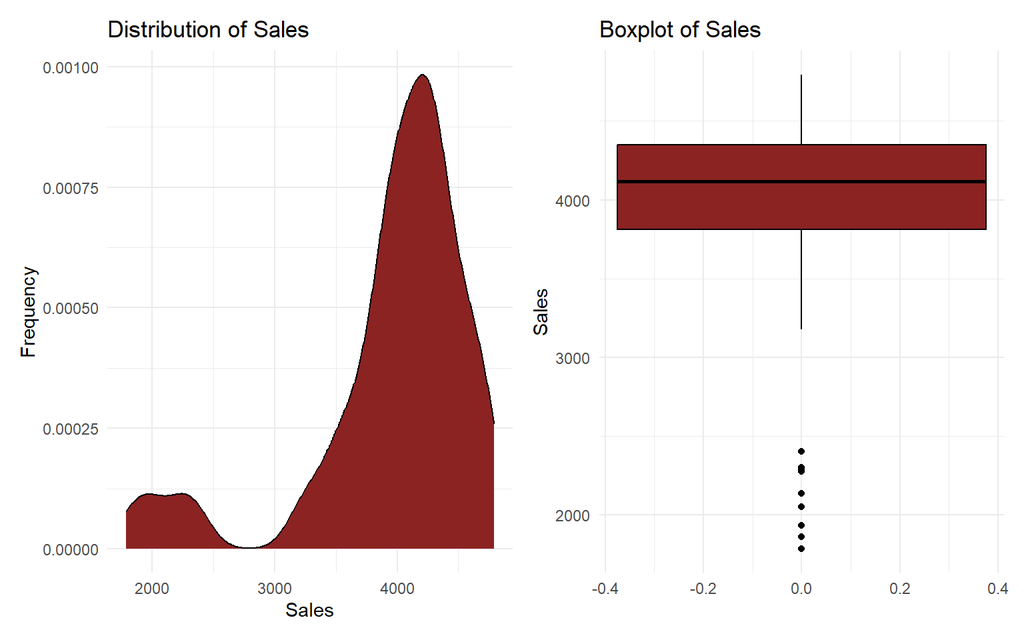

```r
hist_target <- ggplot(mydata, aes(x = Sales)) +
  geom_density(binwidth = 5, fill = "brown4", alpha = 1, color = "black") +
  labs(
    title = "Distribution of Sales",
    x = "Sales",
    y = "Frequency"
  ) +
  theme_minimal()

# Boxplot
boxplot_target <- ggplot(mydata, aes(y = Sales)) +
  geom_boxplot(fill = "brown4", color = "black", alpha = 1) +
  labs(
    title = "Boxplot of Sales",
    y = "Sales"
  ) +
  theme_minimal()


hist_target + boxplot_target
```

The boxplot highlights the presence of some outliers on the lower end of the Sales values. These outliers represent instances with notably lower sales compared to the central tendency of the data. However, the interquartile range (IQR) appears relatively compact, reflecting a relatively stable sales trend for most observations.

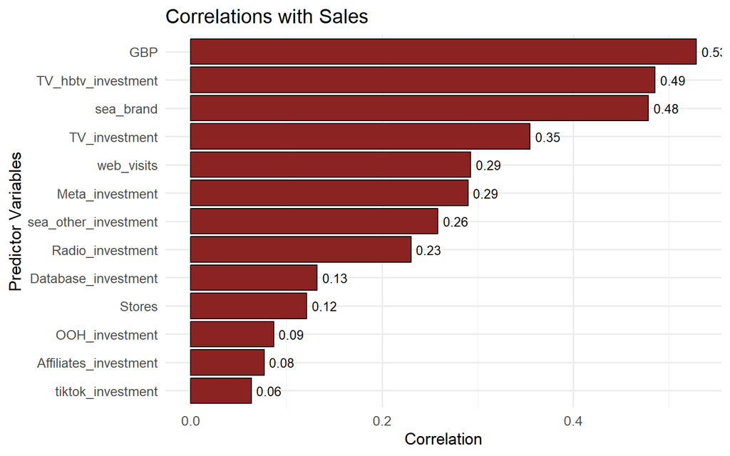

```r
ggplot(correlation_df, aes(x = reorder(Variable, Correlation), y = Correlation)) +
  geom_bar(stat = "identity", fill = "brown4", color = "black", alpha = 1) +
  geom_text(
    aes(label = round(Correlation, 2)),
    hjust = ifelse(correlation_df$Correlation > 0, -0.2, 1.2),
    color = "black",
    size = 3.5
  ) +
  coord_flip() +
  labs(
    title = "Correlations with Sales",
    x = "Predictor Variables",
    y = "Correlation"
  ) +
  theme_minimal(base_size = 13)
```

The correlation chart shows the strength and direction of relationships between the predictor variables and the target variable, `Sales`.

1. **Strongest Correlations**:
   - `GBP` has the highest positive correlation with `Sales`, suggesting that changes in this variable are strongly associated with changes in sales. This could indicate a significant relationship between economic factors and sales performance.
   - `TV_hbtv_investment` and `sea_brand` also exhibit relatively strong positive correlations, emphasizing their importance in influencing sales. Investments in these areas might have a direct impact on sales outcomes.
2. **Moderate Correlations**:
   - Variables such as `TV_investment`, `web_visits`, and `Meta_investment` show moderate positive correlations. These variables likely contribute to sales performance but to a lesser extent than the top predictors. Their inclusion in the model is still valuable for capturing a broader understanding of sales drivers.
3. **Weaker Correlations**:
   - Variables like `Stores`, `OOH_investment`, `Affiliates_investment`, and `tiktok_investment` exhibit weak correlations with `Sales`. These may have a limited or indirect influence on sales and might not be as critical for predictive purposes.

Once the individual correlations with the response variable have been identified, we can examine each predictor variable separately.

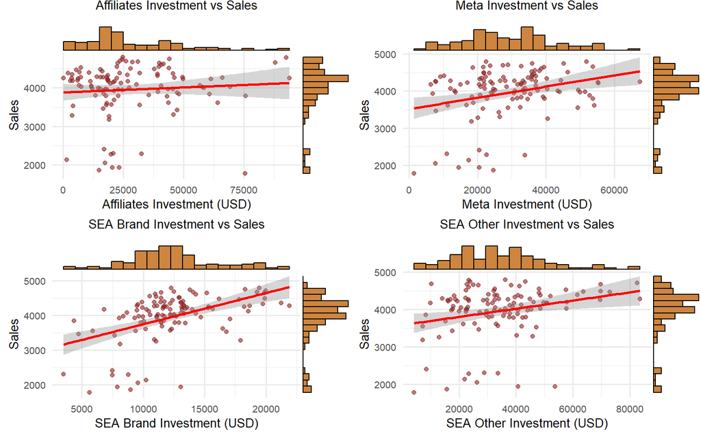

```r
create_scatter_with_marginals <- function(data, x_var, x_label, title) {
  scatter_plot <- ggplot(data, aes_string(x = x_var, y = "Sales")) +
    geom_point(color = "brown4", alpha = 0.6) +
    geom_smooth(method = "lm", color = "red") +
    labs(
      title = title,
      x = x_label,
      y = "Sales"
    ) +
    theme_minimal(base_size = 12) +
    theme(
      plot.title = element_text(size = 10, hjust = 0.5),
      axis.title = element_text(size = 10),
      axis.text = element_text(size = 8)
    )

  ggMarginal(scatter_plot, type = "histogram", fill = "tan3", bins = 20)
}
```

These scatterplots display the relationships between different types of investments (`Affiliates`, `Meta`, `SEA Brand`, and `SEA Other`) and `Sales`:

- **Affiliates Investment** : The plot shows a weak positive trend, indicating that higher investments in affiliates may be associated with slightly increased sales. However, the relationship is not very strong, as evidenced by the scattered points around the regression line.
- **Meta Investment** : There is a clearer positive relationship between `Meta Investment` and `Sales`. Higher investments in Meta-related activities tend to result in increased sales, although there is still some variability in the data.
- **SEA Brand Investment** : This plot highlights a strong positive trend, suggesting that `SEA Brand Investment` is closely linked to higher sales. The points are more aligned with the regression line compared to other variables, indicating a stronger correlation.
- **SEA Other Investment** : Similar to `SEA Brand Investment`, `SEA Other Investment` also shows a positive relationship with `Sales`. However, the spread of the points suggests that the correlation, while significant, is slightly weaker than for `SEA Brand Investment`.

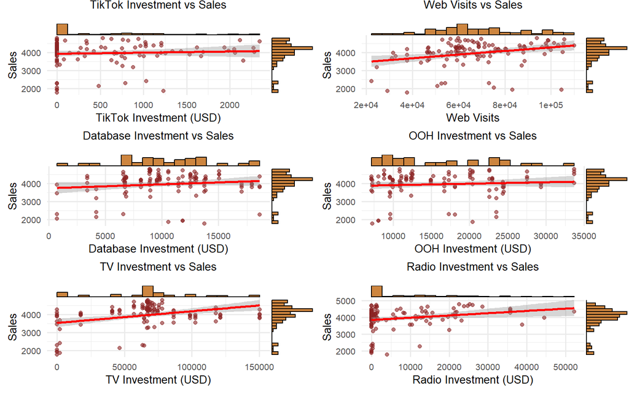

```r
plot_grid(g5, g6, g7, g8, g9, g10, nrow=3, align="v")
```

## Predictor variables

After analyzing the target variable and its relationship with the predictor variables, the focus shifts to examining the predictor variables themselves. This step aims to understand the relationships between them, identify patterns, and detect potential issues such as multicollinearity, which could impact the performance and interpretability of the regression models.

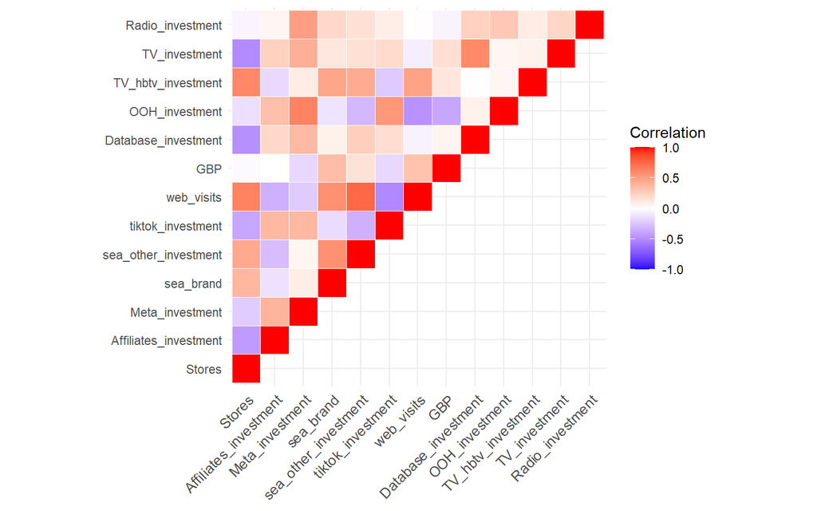

```r
ggplot(correlation_melt_upper, aes(x = Var1, y = Var2, fill = value)) +
  geom_tile(color = "white") +
  scale_fill_gradient2(low = "blue", high = "red", mid = "white",
                       midpoint = 0, limit = c(-1, 1), space = "Lab",
                       name = "Correlation") +
  theme_minimal() +
  theme(axis.text.x = element_text(angle = 45, vjust = 1,
                                   size = 10, hjust = 1),
        axis.title.x = element_blank(),
        axis.title.y = element_blank()) +
  coord_fixed()
```

Moderate Correlated Predictor Variables

| Variable 1 | Variable 2 | Correlation Value |
| --- | --- | --- |
| web_visits | sea_other_investment | 0.7480710 |
| web_visits | Stores | 0.6341590 |
| OOH_investment | Meta_investment | 0.6294009 |
| TV_hbtv_investment | Stores | 0.6071559 |
| TV_investment | Database_investment | 0.5962261 |
| web_visits | sea_brand | 0.5672251 |
| sea_other_investment | sea_brand | 0.5655892 |
| OOH_investment | tiktok_investment | 0.5338578 |
| web_visits | tiktok_investment | -0.5148265 |
| TV_investment | Stores | -0.5005726 |

The table lists the most moderate correlated variable pairs, with correlation values exceeding a threshold of 0.5.

The table highlights pairs of predictor variables with significant correlations, both positive and negative, which are crucial to consider when developing predictive models. Highly correlated variables can lead to multicollinearity issues, potentially affecting the stability and interpretability of model coefficients. Identifying these relationships helps in making informed decisions about feature selection and handling redundancy in the dataset.

Several variables show strong positive correlations. For example, `web_visits` is strongly correlated with both `sea_other_investment` and `Stores`, suggesting a connection between online engagement, marketing investments, and physical store presence. Similarly, `OOH_investment` and `Meta_investment` exhibit a high correlation, possibly reflecting coordinated advertising strategies. Other notable correlations include `TV_hbtv_investment` with `Stores` and `TV_investment` with `Database_investment`, both indicating overlapping influences that should be analyzed further.

Negative correlations also appear in the data. For instance, `web_visits` and `tiktok_investment` have a moderately strong negative correlation, which could indicate differing target audiences or contrasting marketing strategies. Additionally, `TV_investment` and `Stores` are negatively correlated, suggesting that increased TV investments may not align with store-related sales, potentially pointing to different marketing priorities.

### Temporal Trend

A plot is shown to analyze the behavior of the `Sales` variable over time and to identify potential patterns or seasonal effects. This visualization helps assess whether fluctuations in sales follow a recurring trend throughout the observed period.

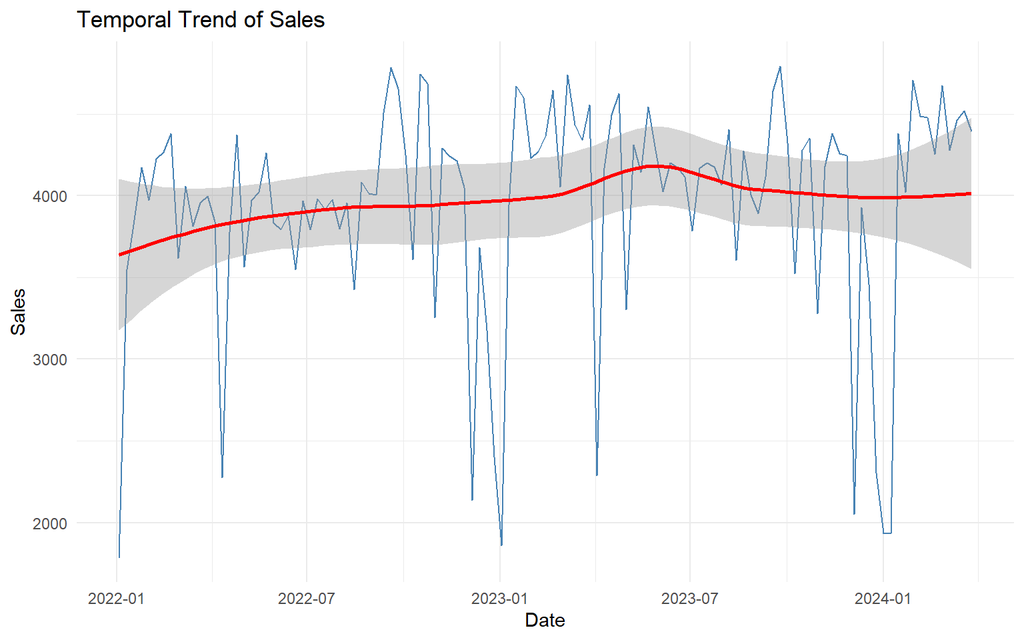

```r
mydata %>%
  ggplot(aes(x = as.Date(Monday_date), y = Sales)) +
  geom_line(color = "steelblue") +
  geom_smooth(method = "loess", color = "red") +
  theme_minimal() +
  labs(
    title = "Temporal Trend of Sales",
    x = "Date",
    y = "Sales"
  )
```

The temporal trend plot of `Sales` shows a slight overall increase in sales from 2022 to early 2024, with the trend stabilizing around mid-2023. While the smoothed red line suggests moderate growth, the raw data (blue line) reveals significant fluctuations, indicating short-term variations possibly due to factors like marketing campaigns or seasonality. Sharp sales drops are visible at certain points, particularly in **April and December**, which might indicate seasonal effects related to the end of campaigns, specific events, or holidays. To capture these effects in the model, it would be useful to include a binary variable indicating whether a week belongs to a key seasonal month, such as April or December. The shaded confidence interval suggests that the smoothed trend provides a reliable representation of the overall sales pattern, despite these fluctuations.

### Outliers

To better understand the data and its potential impact on the modeling process, we will examine the presence of outliers in several key variables. Identifying these atypical values is crucial, as they can significantly influence the results and interpretations of the model.

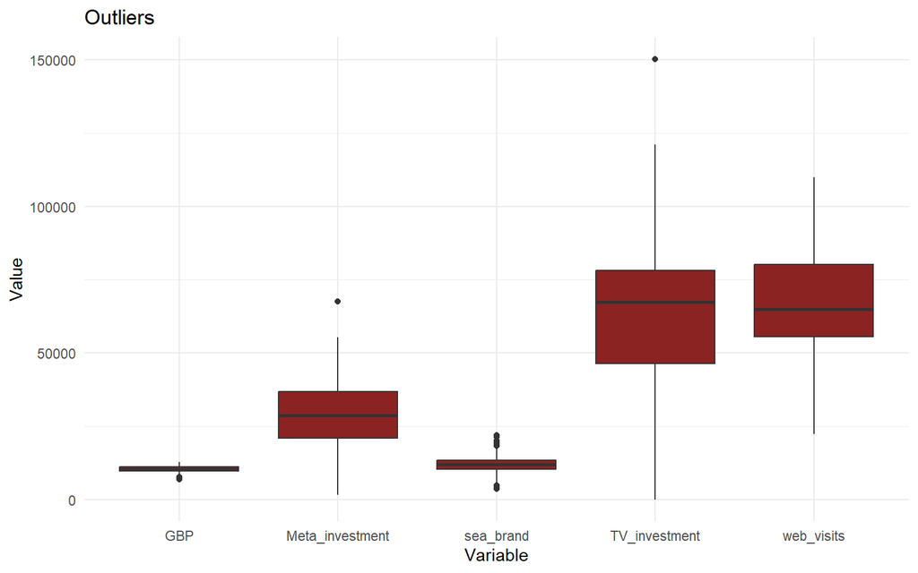

```r
vars_to_check <- c("GBP", "sea_brand", "TV_investment", "web_visits", "Meta_investment")

mydata %>%
  dplyr::select(all_of(vars_to_check)) %>%
  pivot_longer(everything(), names_to = "Variable", values_to = "Value") %>%
  ggplot(aes(x = Variable, y = Value)) +
  geom_boxplot(fill = "brown4") +
  theme_minimal() +
  labs(title = "Outliers", x = "Variable", y = "Value")
```

The results show the presence of some outliers in certain variables, with only a few extreme values detected in most cases (sometimes just one). Given the limited number of these outliers, they do not appear to pose a significant problem for the analysis or modeling process. However, their impact will still be monitored to ensure they do not disproportionately influence the results.

### Digital and Traditional Investment

To enhance the interpretability and efficiency of the analysis, two new variables, `Digital_investment` and `Traditional_investment`, were created by aggregating related categories of investments. `Digital_investment` combines expenditures on platforms such as `Meta_investment`, `tiktok_investment`, `sea_brand`, and `sea_other_investment`, reflecting the overall spending on digital marketing efforts. Similarly, `Traditional_investment` aggregates `TV_investment`, `Radio_investment`, and `OOH_investment`, capturing investments in traditional advertising channels.

```r
mydata4 <- mydata %>%
  mutate(
    Digital_investment = Meta_investment + tiktok_investment + sea_brand + sea_other_investment,
    Traditional_investment = TV_investment + Radio_investment + OOH_investment
  )
```

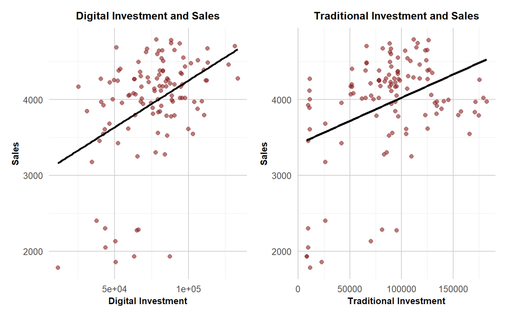

1. **Digital Investment and Sales**:
   - The plot shows a clear positive relationship between `Digital_investment` and `Sales`. As digital investment increases, sales tend to rise. However, there is some scatter around the trend line, particularly for lower levels of investment, which could indicate variability in the effectiveness of digital campaigns or the influence of other factors.
2. **Traditional Investment and Sales**:
   - A positive relationship is also observed between `Traditional_investment` and `Sales`. Higher traditional investment is generally associated with increased sales. The points are slightly more scattered compared to the digital investment plot, suggesting that traditional channels may have a more variable impact on sales.

Both types of investments show a positive association with sales, but the strength of the relationship appears slightly more consistent for `Digital_investment`. This could reflect the growing impact and measurability of digital marketing compared to traditional methods.

Although the initial analysis suggests that the relationships between `Sales` and both `Digital_investment` and `Traditional_investment` appear to be linear, quadratic terms will be included in the model to verify this assumption. Incorporating these terms allows for testing whether there are any non-linear effects, such as diminishing returns at higher levels of investment, which may not be immediately evident in the scatterplots. This ensures that the model captures all potential patterns in the data, providing a more robust and accurate representation of the relationships.

```r
mydata4 <- mydata4 %>%
  mutate(
    Digital_investment_sq = Digital_investment^2,
    Traditional_investment_sq = Traditional_investment^2
  )
```

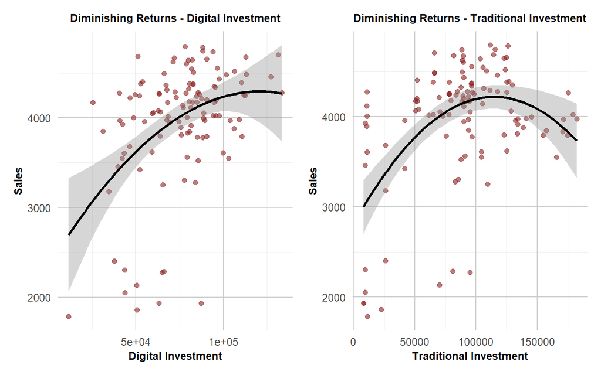

**Digital Investment:** The relationship starts with an upward trend, indicating that increasing digital investments initially leads to higher sales. However, as digital investments grow beyond a certain point, the increase in sales starts to slow down, and the curve begins to flatten. This behavior suggests that there is a **saturation effect**, where additional spending on digital channels yields progressively smaller returns in terms of sales.

**Traditional Investment:** Similarly, traditional investments show an initial positive impact on sales, with higher investments driving greater sales performance. However, after reaching a peak, the trend reverses slightly, indicating that excessive spending on traditional channels may not only result in diminishing returns but could also negatively impact sales. This could reflect oversaturation or inefficiencies in allocating large budgets to traditional media.

To evaluate the model’s performance and ensure robust results, we will use a **nested cross-validation technique**, which is particularly well-suited for problems with limited data. This method is ideal for balancing model selection and evaluation while avoiding overfitting, a common challenge in small datasets.

Nested cross-validation works by splitting the data into two levels of folds: an **outer loop** for model evaluation and an **inner loop** for model selection or hyperparameter tuning. In the outer loop, the data is divided into several folds, with one fold reserved for testing and the remaining folds used for training. For each training fold, the inner loop further splits the data to optimize the model within that subset. This approach ensures that the test set in the outer loop remains unseen during model selection, providing an unbiased estimate of the model’s performance.

In the provided implementation, the outer loop uses 5 folds, and within each fold, a linear regression model is trained on the training set, and its coefficients are tracked. The performance is evaluated using the Mean Absolute Error (MAE) metric on the test fold. This process is repeated for each outer fold, and the average MAE across folds is calculated as a final measure of performance. Additionally, coefficients are summarized to provide insights into model stability.

While it is true that using a simpler train-test methodology with an appropriate seed would likely result in lower MAE values reported in this analysis, such models would be less consistent and potentially overfit to the specific train-test split. This would hinder their ability to generalize effectively to new, unseen data. Since our primary objective is to develop models that are robust and perform well in real-world scenarios, we have prioritized consistency and generalizability through the use of nested cross-validation.

Nested cross-validation is crucial in this case because it maximizes the use of the small dataset while minimizing bias in performance estimates. It provides a reliable framework for model evaluation and ensures that the selected model generalizes well to unseen data.

## Preprocessing

With all the insights gained from the exploratory data analysis, preprocessing decisions will now be applied systematically using a pipeline approach. A pipeline ensures consistency and reproducibility, as it automates sequential data transformations, minimizes manual intervention, and reduces the likelihood of errors.

```r
preprocess_data <- function(data) {

  if (!"Monday_date" %in% colnames(data)) {
    stop("The 'Monday_date' column does not exist in the dataframe.")
  }


  data <- data %>%
    dplyr::mutate(
      Digital_investment = Meta_investment + tiktok_investment + sea_brand + sea_other_investment,
      Traditional_investment = TV_investment + Radio_investment + OOH_investment
    )

  remove <- c("Meta_investment", "sea_brand", "tiktok_investment",
              "sea_other_investment", "TV_investment", "Radio_investment",
              "OOH_investment")
  data <- data %>%
    dplyr::select(-all_of(remove))

  data <- data %>%
    mutate(Monday_date = as.numeric(Monday_date))


  return(data)
}

mydata2 <- preprocess_data(mydata)
outer_test = preprocess_data(outer_test)
new_data <- outer_test %>% dplyr::select(-Sales)
```

# Models

## Linear Regression

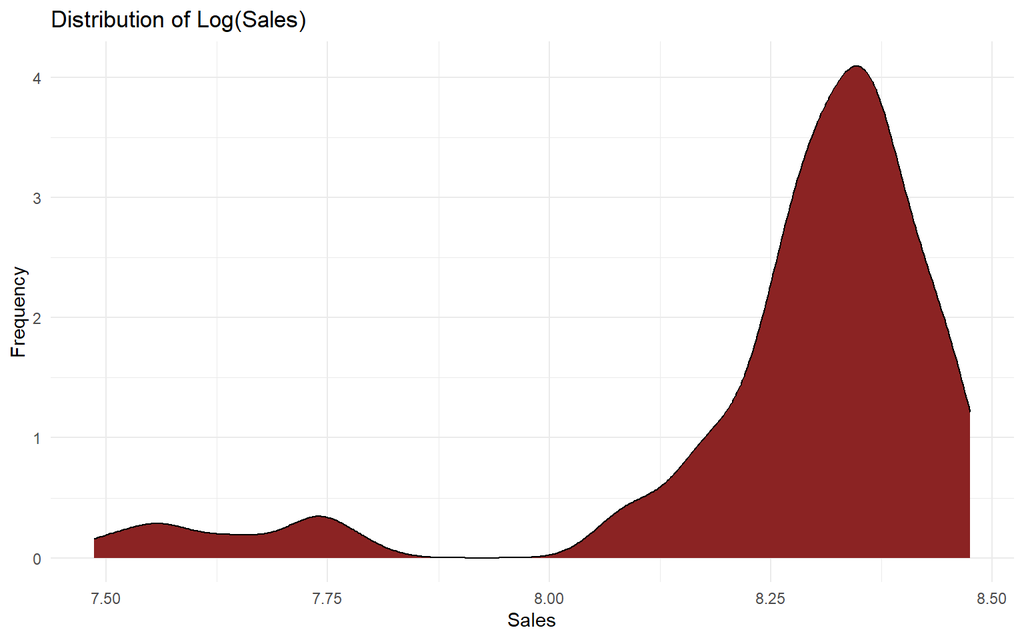

```r
ggplot(mydata, aes(x = log(Sales))) +
  geom_density(binwidth = 5, fill = "brown4", alpha = 1, color = "black") +
  labs(
    title = "Distribution of Log(Sales)",
    x = "Sales",
    y = "Frequency"
  ) +
  theme_minimal()
```

### Benchmark model

A benchmark model is a simple, baseline model used to compare against a more complex model to evaluate its performance. It provides a reference point to determine if the more advanced model adds value. For this case, we chose a benchmark that predicts the median of the dependent variable. This approach is commonly used because it is straightforward, easy to implement, and provides a clear baseline to evaluate whether the stepwise regression model significantly improves prediction accuracy over simply predicting the average.

```r
nested_cv_dummy <- function(data, outer_folds = 5, seed = 100451470) {
  set.seed(seed)

  outer_folds <- createFolds(data$Sales, k = outer_folds, list = TRUE)

  results <- data.frame(Fold = integer(), Dummy_MAE = numeric())

  for (i in seq_along(outer_folds)) {
    test_index <- outer_folds[[i]]
    train_data <- data[-test_index, ]
    test_data <- data[test_index, ]

    median_prediction <- median(train_data$Sales)

    dummy_mae <- mean(abs(test_data$Sales - median_prediction))

    results <- rbind(results, data.frame(Fold = i, Dummy_MAE = dummy_mae))
  }

  mean_dummy_mae <- mean(results$Dummy_MAE)

  cat("\nMean Final Dummy MAE:", round(mean_dummy_mae, 3), "\n")

  return(list(Results = results, Mean_Dummy_MAE = mean_dummy_mae))
}

nested_results_dummy <- nested_cv_dummy(mydata2)
```

```
##
## Mean Final Dummy MAE: 442.522
```

The benchmark model, which predicts the median of the dependent variable `Sales`, achieved a Mean Absolute Error (MAE) of 442.52. This result provides a baseline for evaluating the performance of more complex models, such as the stepwise regression model. If the stepwise regression fails to achieve a significantly lower MAE, it may suggest that the added complexity does not capture meaningful relationships in the data. Consequently, the benchmark model serves as a critical reference point to assess whether the advanced model adds predictive value.

### Full model

First we will make a model with all the variables in the dataset, including the ones that have been created. Different models are created during the nested cross-validation process, each trained and evaluated across the outer folds. While the average Mean Absolute Error (MAE) is calculated to provide an overall measure of performance, the final model presented is the one corresponding to the fold with the lowest MAE in the outer loop. This approach ensures that we identify and utilize the best-performing model while maintaining a robust estimate of generalization performance through the average MAE.

```r
nested_cv_custom <- function(data, formula, outer_folds = 5, inner_folds = 5, seed = 100451470) {
  set.seed(seed)

  outer_folds <- createFolds(data$Sales, k = outer_folds, list = TRUE)

  results <- data.frame(Fold = integer(), MAE = numeric())
  coef_tracking <- list()

  for (i in seq_along(outer_folds)) {

    test_index <- outer_folds[[i]]
    train_data <- data[-test_index, ]
    test_data <- data[test_index, ]

    full_model <- lm(
      formula = formula,
      data = train_data
    )

    coef_tracking[[i]] <- coef(full_model)

    log_predictions <- predict(full_model, newdata = test_data)

    test_data <- test_data %>%
      mutate(Predicted_Sales = exp(log_predictions))

    mae <- mean(abs(test_data$Sales - test_data$Predicted_Sales))

    results <- rbind(results, data.frame(Fold = i, MAE = mae))
  }

  mean_mae <- mean(results$MAE)

  coef_table <- do.call(rbind, lapply(coef_tracking, function(coefs) as.data.frame(t(coefs))))
  coef_summary <- coef_table %>%
    summarise_all(list(mean = mean, sd = sd))

  cat("\nMean Final MAE:", round(mean_mae, 3), "\n")

  return(list(Results = results, Mean_MAE = mean_mae, Coefficient_Summary = coef_summary))
}


nested_results <- nested_cv_custom(mydata2, formula = log(Sales) ~ .)
```

```
##
## Mean Final MAE: 420.651
```

```r
mae_lm_basic <- nested_results$Mean_MAE

best_fold <- which.min(nested_results$Results$MAE)

train_data_best <- mydata2[-nested_results$Results$Fold[best_fold], ]
final_model_lm_basic <- lm(log(Sales) ~ ., data = train_data_best)

summ(final_model_lm_basic, digits = 3)
```

| Observations | 116 |
| --- | --- |
| Dependent variable | log(Sales) |
| Type | OLS linear regression |

| F(9,106) | 17.354 |
| --- | --- |
| R² | 0.596 |
| Adj. R² | 0.561 |

|  | Est. | S.E. | t val. | p |
| --- | --- | --- | --- | --- |
| (Intercept) | 12.610 | 3.888 | 3.244 | 0.002 |
| Monday_date | -0.000 | 0.000 | -1.534 | 0.128 |
| Stores | 0.006 | 0.005 | 1.426 | 0.157 |
| Affiliates_investment | 0.000 | 0.000 | 0.029 | 0.977 |
| web_visits | 0.000 | 0.000 | 0.254 | 0.800 |
| GBP | 0.000 | 0.000 | 7.207 | 0.000 |
| Database_investment | -0.000 | 0.000 | -1.558 | 0.122 |
| TV_hbtv_investment | 0.000 | 0.000 | 2.540 | 0.013 |
| Digital_investment | 0.000 | 0.000 | 1.958 | 0.053 |
| Traditional_investment | 0.000 | 0.000 | 3.012 | 0.003 |

Standard errors: OLS

### Model Interpretation

The final model, adjusted using data from the best fold in nested cross-validation, achieves an R² of 0.596 and an Adjusted R² of 0.561, indicating that approximately 56.1% of the variance in log(Sales) is explained by the predictors. The model’s performance, as measured by the Mean Absolute Error (MAE) of 420.65, suggests that, on average, the predictions of Sales (on the original scale) deviate from the actual values by approximately 420.65 units. This represents an improvement over the dummy benchmark model, which achieved an MAE of 442.52. The reduction in error demonstrates that the final regression model captures meaningful patterns in the data, providing better predictive accuracy compared to a simple median-based prediction.

### Significant Predictors

- **GBP:** Highly significant (p < 0.001) with a positive relationship with log(Sales). This indicates that GBP is a critical factor influencing sales, and higher values are associated with increased sales.
- **TV_hbtv_investment:** Significant positive effect (p = 0.013), suggesting that investment in TV and HBBTV contributes positively to sales.
- **Traditional_investment:** Significant positive effect (p = 0.003), indicating that traditional media investments (e.g., TV, radio, and OOH) positively impact sales.
- **Digital_investment:** Borderline significant (p = 0.053), suggesting a potential positive impact on sales, though this effect is less robust than other significant predictors.

### Non-Significant Predictors

- **Monday_date (p = 0.128):** While showing a negative trend, this predictor is not statistically significant and does not contribute meaningfully to explaining sales variance.
- **Stores (p = 0.157):** The number of stores exhibits a positive relationship with sales, but the effect is not statistically significant.
- **Affiliates_investment (p = 0.977):** This predictor does not show a meaningful effect on sales.
- **web_visits (p = 0.800):** Website visits are not significant, suggesting limited explanatory power in this context.
- **Database_investment (p = 0.122):** Although negative, this variable is not statistically significant in explaining sales.

### Model with interactions

At this stage, a new model is fitted by exploring various combinations of interactions and quadratic terms for the predictor variables. This approach allows us to capture potential non-linear relationships and complex interactions between the variables that might better explain the variability in `Sales`. By systematically testing these terms, the goal is to improve the model’s predictive performance and provide a more accurate representation of the underlying relationships within the data.

```r
nested_results <- nested_cv_custom(mydata2, formula = log(Sales) ~ Monday_date + Affiliates_investment  + GBP +  Database_investment   + Traditional_investment + I(Traditional_investment^2) + I(Digital_investment^2) + I(GBP^2) + Affiliates_investment : Digital_investment + GBP : Digital_investment + Monday_date : Digital_investment)
```

```
##
## Mean Final MAE: 329.304
```

```r
mae_lm_int = nested_results$Mean_MAE
```

| Observations | 116 |
| --- | --- |
| Dependent variable | log(Sales) |
| Type | OLS linear regression |

| F(11,104) | 26.850 |
| --- | --- |
| R² | 0.740 |
| Adj. R² | 0.712 |

|  | Est. | S.E. | t val. | p |
| --- | --- | --- | --- | --- |
| (Intercept) | 2.184 | 1.671 | 1.307 | 0.194 |
| Monday_date | 0.000 | 0.000 | 0.042 | 0.966 |
| Affiliates_investment | -0.000 | 0.000 | -1.371 | 0.173 |
| GBP | 0.001 | 0.000 | 7.212 | 0.000 |
| Database_investment | -0.000 | 0.000 | -2.721 | 0.008 |
| Traditional_investment | 0.000 | 0.000 | 6.280 | 0.000 |
| I(Traditional_investment^2) | -0.000 | 0.000 | -5.282 | 0.000 |
| I(Digital_investment^2) | 0.000 | 0.000 | 0.298 | 0.766 |
| I(GBP^2) | -0.000 | 0.000 | -5.749 | 0.000 |
| Affiliates_investment:Digital_investment | 0.000 | 0.000 | 1.576 | 0.118 |
| GBP:Digital_investment | -0.000 | 0.000 | -3.770 | 0.000 |
| Monday_date:Digital_investment | 0.000 | 0.000 | 2.915 | 0.004 |

Standard errors: OLS

### Model Interpretation

The final model, adjusted using data from the best fold in nested cross-validation, achieves an R² of 0.740 and an Adjusted R² of 0.712, indicating that approximately 74.0% of the variance in log(Sales) is explained by the predictors. The model’s performance, as measured by the Mean Absolute Error (MAE) of 329.30, demonstrates that, on average, the predictions of Sales (in the original scale) deviate from the actual values by approximately 329 units. This represents a notable improvement compared to simpler models and confirms that the final regression model effectively captures meaningful patterns in the data, enhancing predictive accuracy over baseline approaches.

### Significant Predictors

- **GBP:** Highly significant (p < 0.001) with a strong positive relationship with log(Sales). This highlights GBP as a key driver of sales.
- **Traditional_investment and I(Traditional_investment²):** The linear term (p < 0.001) is positively associated with sales, while the quadratic term (p < 0.001) is negative, indicating diminishing returns at higher levels of traditional investment.
- **I(GBP²):** Negative and significant (p < 0.001), reflecting diminishing returns or saturation effects as GBP increases.
- **Monday_date:Digital_investment:** Positive and significant (p = 0.004), suggesting that the impact of digital investment on sales varies over time, potentially due to seasonality or campaign-related factors.
- **GBP:Digital_investment:** Negative and significant (p < 0.001), implying a combined effect of these variables that reduces sales, possibly due to inefficiencies or conflicts between GBP value and digital investment strategies.
- **Database_investment:** Negative and significant (p = 0.008), indicating that higher investment in databases correlates with lower sales, which may point to inefficiencies or misallocation of resources in this area.

### Non-Significant Predictors

- **Monday_date (p = 0.966):** The overall time trend does not significantly affect sales independently, suggesting its effect is captured through interactions.
- **Affiliates_investment (p = 0.173):** While included in the model, this variable does not contribute significantly, indicating limited impact on sales.
- **I(Digital_investment²) (p = 0.766):** The quadratic term for digital investment is not significant, suggesting that diminishing returns are not strongly present for this variable.
- **Affiliates_investment:Digital_investment (p = 0.118):** The interaction between these variables is not statistically significant, suggesting no strong combined effect.

### Best Feature Selection

A **best feature selection** process will be performed to identify the most relevant predictors and interactions that contribute significantly to explaining `Sales`. This approach aims to refine the model by systematically evaluating and selecting variables that improve predictive accuracy while maintaining simplicity and interpretability. By eliminating redundant or non-significant predictors, the model can achieve better generalization, reduce overfitting, and enhance overall performance.

```
##
## Mean Final MAE: 327.663
```

To select the best model, we use a variable selection approach based on frequency analysis during the nested cross-validation process. At each iteration of the outer folds, stepwise selection is applied to identify the most relevant predictors for explaining `Sales`. The variables selected in each fold are tracked, and their selection frequency across all folds is calculated. Only variables that appear in at least **80% of the outer folds** are included in the final model. This ensures that the final model focuses on predictors that consistently contribute to the model’s performance, improving interpretability and robustness while reducing the risk of including spurious variables.

Variable Frequencies Table

| Var1 | Freq |
| --- | --- |
| (Intercept) | 5 |
| Database_investment | 5 |
| GBP | 5 |
| GBP:Digital_investment | 5 |
| I(GBP^2) | 5 |
| I(Traditional_investment^2) | 5 |
| Traditional_investment | 5 |
| Monday_date | 4 |
| Monday_date:Digital_investment | 4 |
| Affiliates_investment | 3 |
| Affiliates_investment:Digital_investment | 3 |

```r
n_outer_folds <- 5

top_variables <- nested_results$Variable_Frequencies %>%
  filter(Freq >= 0.8 * n_outer_folds) %>%
  pull(Var1) %>%
  setdiff("(Intercept)")

final_model_formula <- as.formula(paste("log(Sales) ~", paste(top_variables, collapse = " + ")))

final_model_bfs <- lm(final_model_formula, data = mydata2)

summ(final_model_bfs)
```

| Observations | 117 |
| --- | --- |
| Dependent variable | log(Sales) |
| Type | OLS linear regression |

| F(8,108) | 36.65 |
| --- | --- |
| R² | 0.73 |
| Adj. R² | 0.71 |

|  | Est. | S.E. | t val. | p |
| --- | --- | --- | --- | --- |
| (Intercept) | 2.59 | 1.57 | 1.65 | 0.10 |
| Database_investment | -0.00 | 0.00 | -3.61 | 0.00 |
| GBP | 0.00 | 0.00 | 7.23 | 0.00 |
| I(GBP^2) | -0.00 | 0.00 | -5.72 | 0.00 |
| I(Traditional_investment^2) | -0.00 | 0.00 | -5.28 | 0.00 |
| Traditional_investment | 0.00 | 0.00 | 6.52 | 0.00 |
| Monday_date | -0.00 | 0.00 | -0.21 | 0.84 |
| GBP:Digital_investment | -0.00 | 0.00 | -3.92 | 0.00 |
| Digital_investment:Monday_date | 0.00 | 0.00 | 4.06 | 0.00 |

Standard errors: OLS

The final model, selected using variable frequency analysis during nested cross-validation, explains approximately **73% of the variance** in `log(Sales)`. This indicates a strong fit and suggests that the selected predictors effectively capture the variability in sales. The model includes a reduced set of variables that consistently contribute to performance across folds, focusing on the most impactful predictors.

1. **Significant Predictors** ($p < 0.05$):
   - **`Database_investment`** ($p = 0.00$): Negatively associated with `log(Sales)`, indicating diminishing returns or inefficiencies in this type of investment.
   - **`GBP`** ($p = 0.00$): Strong positive association with `log(Sales)`, emphasizing its critical role in driving sales.
   - **`I(GBP^2)`** ($p = 0.00$): Negative quadratic effect, confirming diminishing returns as GBP increases.
   - **`Traditional_investment`** ($p = 0.00$) and **`I(Traditional_investment^2)`** ($p = 0.00$): Positive linear effect with a negative quadratic term, indicating that while traditional investments initially boost sales, their impact decreases at higher levels.
   - **`GBP:Digital_investment`** ($p = 0.00$): Negative interaction, suggesting that the combined effect of GBP and digital investment reduces sales, possibly due to oversaturation or inefficiencies.
   - **`Digital_investment:Monday_date`** ($p = 0.00$): Positive interaction, showing that the impact of digital investments on sales varies over time, potentially reflecting seasonal or campaign-specific effects.
2. **Non-Significant Predictors** ($p > 0.05$):
   - **`Monday_date`** ($p = 0.84$): The overall time trend does not significantly affect sales independently, suggesting that time-dependent effects are captured through interactions.

The final model achieves a lower MAE ($327$) compared to earlier models ($329$ in the full nested CV). This indicates an improvement in predictive accuracy. - **Reduced Complexity**: - The model includes only 8 predictors, compared to a larger set in previous iterations. This reduction simplifies interpretation while maintaining strong predictive performance.

The final model is an improvement over previous models due to its lower MAE and reduced number of predictors. By focusing on the most impactful variables, the model achieves a balance between simplicity, interpretability, and accuracy, making it a more robust tool for understanding and predicting `Sales`.

Now that the final model has been selected, it is crucial to verify whether the necessary assumptions for linear regression have been met. These assumptions include the normality of residuals, homoscedasticity (constant variance of residuals), independence of residuals, and linearity of relationships between predictors and the target variable. To assess these conditions, diagnostic plots were generated and statistical tests were performed:

- **Kolmogorov-Smirnov Test:** This test evaluates whether the residuals follow a normal distribution.
- **Breusch-Pagan Test:** This test checks for homoscedasticity, ensuring that the variance of the residuals remains constant across fitted values.

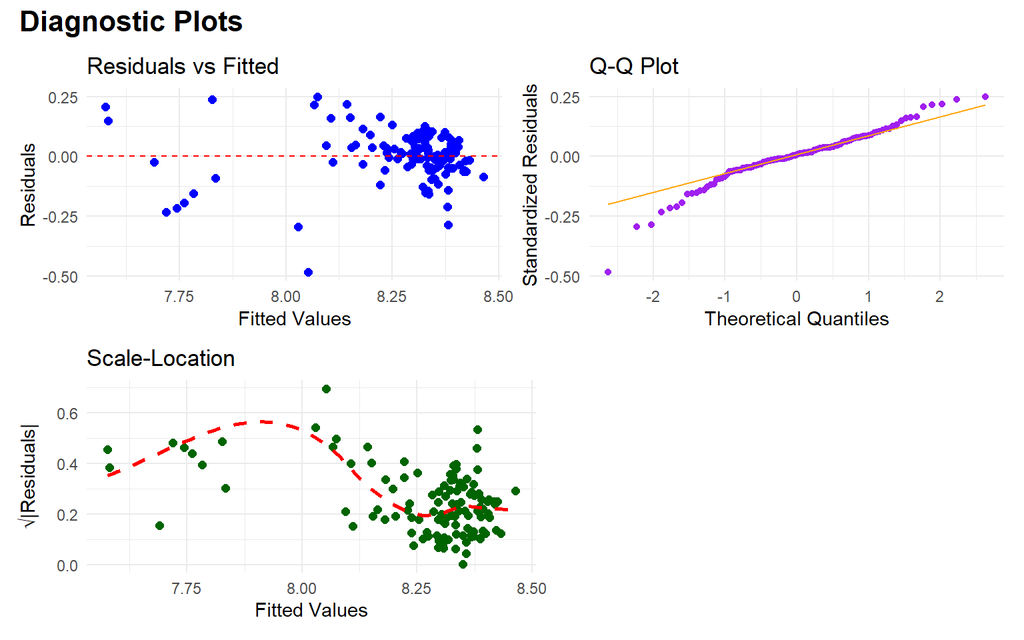

```r
residuals <- residuals(final_model_bfs)

ks_test <- ks.test(residuals, "pnorm", mean(residuals), sd(residuals))


bp_test <- bptest(final_model_bfs)
```

Diagnostic Test Results

|  | Test | p.value | Conclusion |
| --- | --- | --- | --- |
|  | Kolmogorov-Smirnov Test | 0.1004973 | Residuals likely follow a normal distribution. |
| BP | Breusch-Pagan Test | 0.0003630 | Residuals do not have constant variance (heteroscedasticity). |

The diagnostic tests reveal that the residuals likely follow a normal distribution, as indicated by the Kolmogorov-Smirnov test (p-value = 0.1005). However, the Breusch-Pagan test (p-value = 0.0004) shows evidence of heteroscedasticity, meaning the variance of the residuals is not constant.

We can plot some graphs to see the effects of some variables in the model.

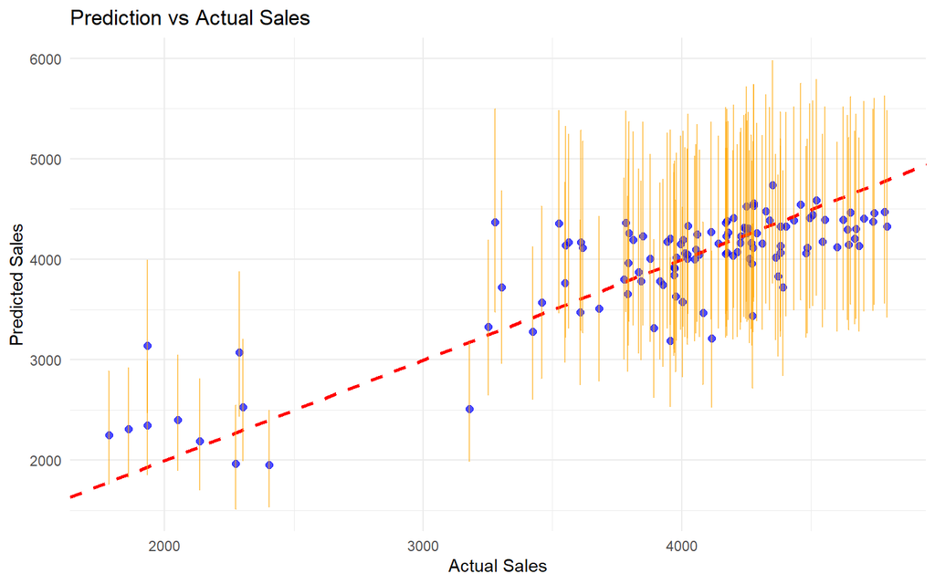

Finally, the plot compares the predicted sales values with the actual observed values, providing a visual assessment of the model’s predictive performance. The vertical error bars represent prediction intervals, which indicate the range where a new observation is likely to fall, considering both the uncertainty of the model and the inherent variability of the data.

### Lasso

LASSO (Least Absolute Shrinkage and Selection Operator) is a regression technique that performs variable selection and regularization to enhance the predictive accuracy and interpretability of statistical models. It works by adding a penalty term to the ordinary least squares (OLS) loss function, proportional to the absolute values of the regression coefficients.

This penalty causes some coefficients to shrink towards zero, effectively excluding less important predictors from the model. By doing so, LASSO is particularly effective in addressing multicollinearity among predictors and simplifying models.

```r
nested_cv_lasso <- function(data, formula, outer_folds = 5, seed = 100451470) {
  set.seed(seed)

  outer_folds <- createFolds(data$Sales, k = outer_folds, list = TRUE)

  results <- data.frame(Fold = integer(), MAE = numeric())
  coef_tracking <- list()
  final_model <- NULL

  for (i in seq_along(outer_folds)) {
    test_index <- outer_folds[[i]]
    train_data <- data[-test_index, ]
    test_data <- data[test_index, ]

    x_train <- model.matrix(formula, train_data)[, -1]
    y_train <- log(train_data$Sales)
    x_test <- model.matrix(formula, test_data)[, -1]
    y_test <- test_data$Sales

    cv_lasso <- cv.glmnet(x_train, y_train, alpha = 1)
    best_lambda <- cv_lasso$lambda.min

    lasso_model <- glmnet(x_train, y_train, alpha = 1, lambda = best_lambda)
    coef_tracking[[i]] <- as.vector(coef(lasso_model))

    if (i == length(outer_folds)) {
      final_model <- lasso_model
    }

    log_predictions <- predict(lasso_model, s = best_lambda, newx = x_test)
    test_data$Predicted_Sales <- exp(log_predictions)

    mae <- mean(abs(y_test - test_data$Predicted_Sales))
    results <- rbind(results, data.frame(Fold = i, MAE = mae))
  }

  mean_mae <- mean(results$MAE)

  coef_table <- do.call(rbind, coef_tracking)
  coef_summary <- data.frame(
    Mean = apply(coef_table, 2, mean),
    SD = apply(coef_table, 2, sd)
  )

  # Print the final mean MAE
  cat("\nMean Final MAE:", round(mean_mae, 3), "\n")

  return(list(Results = results, Mean_MAE = mean_mae, Coefficient_Summary = coef_summary, Final_Model = final_model))

}
```

```r
nested_results_lasso <- nested_cv_lasso(mydata2, formula = log(Sales) ~  Monday_date + Affiliates_investment  + GBP +  Database_investment   + Traditional_investment + I(Traditional_investment^2) + I(GBP^2) + Digital_investment)
```

```
##
## Mean Final MAE: 328.819
```

```r
mae_lasso = nested_results_lasso$Mean_MAE
lasso_model <- nested_results_lasso$Final_Model
```

Non-Zero Coefficients from LASSO Model

| Variable | Coefficient |
| --- | --- |
| (Intercept) | 1.6229987 |
| Monday_date | 0.0000000 |
| Affiliates_investment | 0.0000001 |
| GBP | 0.0008149 |
| Database_investment | -0.0000097 |
| Traditional_investment | 0.0000072 |
| I(Traditional_investment^2) | 0.0000000 |
| I(GBP^2) | 0.0000000 |
| Digital_investment | 0.0000006 |

### Ridge

Ridge regression is a regression technique that addresses multicollinearity and improves model stability by adding a penalty term to the ordinary least squares (OLS) loss function, proportional to the squared values of the regression coefficients. This penalty discourages large coefficients, effectively shrinking them towards zero but not exactly to zero, ensuring all predictors remain in the model. By controlling the magnitude of coefficients, Ridge regression enhances the predictive performance and reduces overfitting, making it particularly effective when dealing with datasets that have highly correlated predictors or a large number of features.

```r
nested_cv_ridge <- function(data, formula, outer_folds = 5, seed = 100451470) {
  set.seed(seed)

  outer_folds <- createFolds(data$Sales, k = outer_folds, list = TRUE)

  results <- data.frame(Fold = integer(), MAE = numeric())
  coef_tracking <- list()
  final_model <- NULL

  for (i in seq_along(outer_folds)) {
    test_index <- outer_folds[[i]]
    train_data <- data[-test_index, ]
    test_data <- data[test_index, ]

    x_train <- model.matrix(formula, train_data)[, -1]
    y_train <- log(train_data$Sales)
    x_test <- model.matrix(formula, test_data)[, -1]
    y_test <- test_data$Sales

    cv_ridge <- cv.glmnet(x_train, y_train, alpha = 0)
    best_lambda <- cv_ridge$lambda.min

    ridge_model <- glmnet(x_train, y_train, alpha = 0, lambda = best_lambda)
    coef_tracking[[i]] <- as.vector(coef(ridge_model))

    if (i == length(outer_folds)) {
      final_model <- ridge_model
    }

    log_predictions <- predict(ridge_model, s = best_lambda, newx = x_test)
    test_data$Predicted_Sales <- exp(log_predictions)

    mae <- mean(abs(y_test - test_data$Predicted_Sales))
    results <- rbind(results, data.frame(Fold = i, MAE = mae))
  }

  mean_mae <- mean(results$MAE)
  coef_table <- do.call(rbind, coef_tracking)
  coef_summary <- data.frame(
    Mean = apply(coef_table, 2, mean),
    SD = apply(coef_table, 2, sd)
  )

  cat("\nMean Final MAE:", round(mean_mae, 3), "\n")
  return(list(Results = results, Mean_MAE = mean_mae, Coefficient_Summary = coef_summary, Final_Model = final_model))
}
nested_results_ridge <- nested_cv_ridge(mydata2, formula = log(Sales) ~  .)
```

```
##
## Mean Final MAE: 402.123
```

```r
mae_ridge = nested_results_ridge$Mean_MAE
ridge_model = nested_results_ridge$Final_Model
```

Non-Zero Coefficients from Ridge Model

| Variable | Coefficient |
| --- | --- |
| (Intercept) | 8.7871726 |
| Monday_date | 0.0000000 |
| Stores | 0.0036594 |
| Affiliates_investment | -0.0000001 |
| web_visits | -0.0000013 |
| GBP | 0.0000914 |
| Database_investment | -0.0000060 |
| TV_hbtv_investment | 0.0000127 |
| Digital_investment | 0.0000022 |
| Traditional_investment | 0.0000016 |

### Comparison

We can compare the statistical models.

Mean Absolute Errors (MAE) of Models

[output not shown]

```r
modelA = Sales ~ Database_investment + GBP + GBP:Digital_investment +
    I(GBP^2) + I(Traditional_investment^2) + Traditional_investment +
    Monday_date + Monday_date:Digital_investment
```

## Machine learning models

To create machine learning models, we have developed a generic function that will serve as a flexible and reusable tool for evaluating different models. The function, `nested_cv_generic`, implements a nested cross-validation approach to assess model performance while tuning hyperparameters. It divides the data into outer and inner folds, ensuring robust validation and minimizing overfitting. The function can handle various machine learning algorithms specified by the user (`model_name`) and applies preprocessing steps such as centering and scaling. By calculating metrics like Mean Absolute Error (MAE) for each fold, it identifies the best hyperparameters and provides a comprehensive evaluation of each model’s performance.

```r
nested_cv_generic <- function(data, formula, model_name, hp_grid, folds = 5, inner_repeats = 5, seed = 100451470) {
  set.seed(seed)

  outer_folds <- createFolds(data[[all.vars(formula)[1]]], k = folds)

  results <- data.frame(Fold = integer(), MAE = numeric())
  best_hyperparameters <- list()
  fitted_models <- list()

  for (i in seq_along(outer_folds)) {

    test_index <- outer_folds[[i]]
    train_data <- data[-test_index, ]
    test_data <- data[test_index, ]

    inner_control <- trainControl(
      method = "repeatedcv",
      number = folds,
      repeats = inner_repeats,
      verboseIter = FALSE,
      summaryFunction = defaultSummary
    )

    model <- train(
      formula,
      data = train_data,
      method = model_name,
      trControl = inner_control,
      metric = "MAE",
      tuneGrid = hp_grid,
      preProcess = c("center", "scale")
    )

    fitted_models[[i]] <- model

    best_hyperparameters[[i]] <- model$bestTune

    predictions <- predict(model, newdata = test_data)
    mae <- mean(abs(predictions - test_data[[all.vars(formula)[1]]]))

    results <- rbind(results, data.frame(Fold = i, MAE = mae))
  }

  mean_mae <- mean(results$MAE, na.rm = TRUE)
  cat("\nMean Final MAE:", mean_mae, "\n")

  return(list(
    Results = results,
    Mean_MAE = mean_mae,
    Best_Hyperparameters = best_hyperparameters,
    Fitted_Models = fitted_models
  ))
}
```

To predict future data using multiple models, we created the `predict_with_multiple_models` function. This function takes a list of trained models and a new dataset as input, generating predictions for each model and combining them to produce averaged predictions. For each model, predictions are stored in a structured format, allowing us to evaluate the individual contributions of different models. The final prediction for each observation is calculated as the mean of predictions across all models. This approach leverages the ensemble effect, improving prediction robustness and accuracy by reducing potential biases from individual models.

```r
predict_with_multiple_models <- function(models, new_data) {
  individual_predictions <- data.frame(row.names = seq_len(nrow(new_data)))

  for (i in seq_along(models)) {
    individual_predictions[[paste0("Fold_", i)]] <- predict(models[[i]], newdata = new_data)
  }

  averaged_predictions <- rowMeans(individual_predictions, na.rm = TRUE)

  return(data.frame(Predicted = averaged_predictions))
}
```

### KNN

K-Nearest Neighbors (KNN) is a simple algorithm used for regression and classification. It predicts outcomes based on the average value (regression) or majority class (classification) of the `k` nearest data points, determined by a distance metric like Euclidean distance. The hyperparameter `k` defines the number of neighbors considered, with smaller values capturing local patterns and larger values providing smoother predictions. In this case, the `knn_grid` tests values of `k` from 1 to 30 (in steps of 2) to identify the optimal value that minimizes the Mean Absolute Error (MAE) during nested cross-validation.

```r
knn_grid <- expand.grid(k = seq(1, 30, by = 2))

knn_results <- nested_cv_generic(
  data = mydata2,
  formula = modelA,
  model_name = "knn",
  hp_grid = knn_grid,
  folds = 5,
  inner_repeats = 3
)
```

```
##
## Mean Final MAE: 307.036
```

```r
fitted_knn_models <- knn_results$Fitted_Model

knn_predictions <- predict_with_multiple_models(
  models = fitted_knn_models,
  new_data = new_data
)
knn_pred = knn_predictions$Predicted
```

### Random Forest

Random Forest (RF) is a versatile ensemble learning method that builds multiple decision trees during training and combines their outputs to make predictions. For regression, it averages the predictions of individual trees, reducing overfitting and improving accuracy. The key hyperparameter `mtry` determines the number of features randomly selected at each tree split, controlling the model’s diversity and performance. In this case, the `rf_grid` explores values of `mtry` from 2 to 8 to find the optimal number of features, ensuring robust performance by minimizing the Mean Absolute Error (MAE) during nested cross-validation.

```r
rf_grid <- expand.grid(mtry = c(2,3,4,5,6,7,8))

rf_results <- nested_cv_generic(
  data = mydata2,
  formula = modelA,
  model_name = "rf",
  hp_grid = rf_grid,
  folds = 5,
  inner_repeats = 3
)
```

```
##
## Mean Final MAE: 280.4164
```

Best Hyperparameters for Random Forest

| Fold | Mtry |
| --- | --- |
| 1 | 5 |
| 2 | 6 |
| 3 | 6 |
| 4 | 2 |
| 5 | 3 |

```r
fitted_rf_models <- rf_results$Fitted_Model
rf_predictions <- predict_with_multiple_models(
  models = fitted_rf_models,
  new_data = new_data
)
rf_pred = rf_predictions$Predicted
```

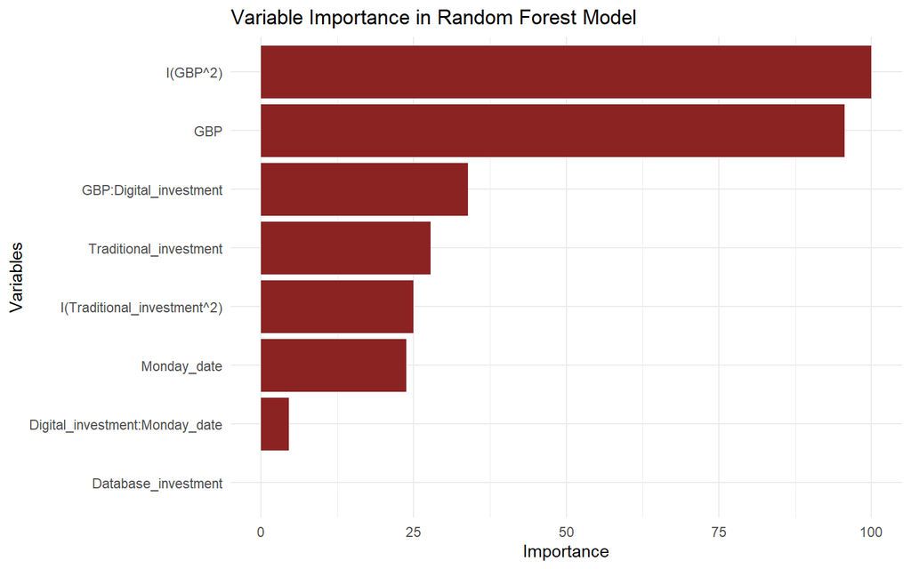

The variable importance chart highlights that **GBP** and its squared term (**I(GBP²)**) are the most influential predictors in the Random Forest model, suggesting a strong and nonlinear relationship with the target variable. Interactions like **GBP:Digital_investment** and **Traditional_investment** (including its quadratic term) also play a significant role, indicating the importance of these variables and their diminishing returns. **Monday_date** shows moderate importance, likely capturing time-related effects, while **Digital_investment:Monday_date** and **Database_investment** have lower contributions, reflecting a smaller impact on the predictions.

### Gradient Boosting Machines

Gradient Boosting Machines (GBM) is a powerful ensemble learning method that builds models sequentially by combining weak learners, typically decision trees, to minimize errors. It uses key hyperparameters like `interaction.depth` (tree depth), `n.trees` (number of trees), `shrinkage` (learning rate), and `n.minobsinnode` (minimum observations per node) to control model complexity and performance. In this case, the `gbm_grid` tests combinations of these hyperparameters to find the optimal configuration, ensuring robust predictions by minimizing Mean Absolute Error (MAE) through nested cross-validation.

```r
gbm_grid <- expand.grid(
  interaction.depth = c(1, 3, 5),
  n.trees = c(50, 100, 150),
  shrinkage = c(0.01, 0.1),
  n.minobsinnode = c(10, 20)
)

gbm_results <- nested_cv_generic(
  data = mydata2,
  formula = modelA,
  model_name = "gbm",
  hp_grid = gbm_grid,
  folds = 5,
  inner_repeats = 3
)
```

```
Mean Final MAE: 323.8372
```

### Cubist

Cubist is a rule-based machine learning algorithm that combines decision trees and linear regression models to make predictions. It creates rules from the data and fits a linear regression model for each rule, allowing it to capture both nonlinear patterns and numeric relationships. The key hyperparameters include `committees`, which defines the number of models combined in an ensemble to improve accuracy, and `neighbors`, which specifies the number of nearby data points used to adjust predictions. In this case, the `cubist_grid` explores combinations of these hyperparameters to identify the best configuration through nested cross-validation, minimizing the Mean Absolute Error (MAE).

```r
cubist_grid <- expand.grid(
  committees = c(10, 50, 75),
  neighbors = c(1,3,5)
)


cubist_results <- nested_cv_generic(
  data = mydata2,
  formula = modelA,
  model_name = "cubist",
  hp_grid = cubist_grid,
  folds = 5,
  inner_repeats = 3
)
```

```
Mean Final MAE: 291.2742
```

Best Hyperparameters for Cubist

| Fold | Committees | Neighbors |
| --- | --- | --- |
| 1 | 75 | 5 |
| 2 | 50 | 3 |
| 3 | 10 | 5 |
| 4 | 75 | 3 |
| 5 | 50 | 5 |

```r
fitted_cubist_models <- cubist_results$Fitted_Model
cubist_predictions <- predict_with_multiple_models(
  models = fitted_cubist_models,
  new_data = new_data
)
cubist_pred = cubist_predictions$Predicted
```

### Elastic Net

Elastic Net is a regularization technique that combines the strengths of both Lasso (L1) and Ridge (L2) regression. It introduces two key hyperparameters: `alpha`, which controls the balance between Lasso and Ridge penalties, and `lambda`, which determines the overall regularization strength. This flexibility allows Elastic Net to handle multicollinearity effectively and select relevant features. The `elastic_net_grid` explores combinations of `alpha` (ranging from 0.2 to 0.8) and `lambda` (ranging across several magnitudes) to find the optimal configuration using nested cross-validation, minimizing the Mean Absolute Error (MAE) for robust predictive performance.

```r
elastic_net_grid <- expand.grid(
  alpha = seq(0.2, 0.8, by = 0.05),
  lambda = 10^seq(-4, 1, length = 10)
)

elastic_net_results <- nested_cv_generic(
  data = mydata2,
  formula = modelA,
  model_name = "glmnet",
  hp_grid = elastic_net_grid,
  folds = 5,
  inner_repeats = 3
)
```

```
##
## Mean Final MAE: 295.4045
```

Best Hyperparameters for Elastic Net

| Fold | Alpha | Lambda |
| --- | --- | --- |
| 1 | 0.20 | 0.2154435 |
| 2 | 0.75 | 0.0166810 |
| 3 | 0.20 | 0.2154435 |
| 4 | 0.25 | 0.0599484 |
| 5 | 0.55 | 0.0166810 |

```r
fitted_elastic_net_models <- elastic_net_results$Fitted_Model
elastic_net_predictions <- predict_with_multiple_models(
  models = fitted_elastic_net_models,
  new_data = new_data
)
elastic_net_pred = elastic_net_predictions$Predicted
```

### XGBoost

XGBoost (Extreme Gradient Boosting) is a highly efficient and scalable machine learning algorithm based on gradient boosting. It builds decision trees sequentially to minimize errors, optimizing both speed and performance. Key hyperparameters include `nrounds` (number of boosting iterations), `eta` (learning rate to control step size), and `max_depth` (tree depth to capture complexity). Other parameters like `gamma` (penalty for splitting nodes), `colsample_bytree` (fraction of features per tree), `min_child_weight` (minimum weight for leaf nodes), and `subsample` (fraction of data used per iteration) help prevent overfitting. The `xgb_grid` explores these combinations to identify the best configuration, ensuring robust predictions by minimizing the Mean Absolute Error (MAE) through nested cross-validation.

```r
xgb_grid <- expand.grid(
  nrounds = 150,
  eta = 0.1,
  max_depth = 6,
  gamma = 0,
  colsample_bytree = 0.8,
  min_child_weight = 5,
  subsample = 0.8
)

xgb_results <- nested_cv_generic(
  data = mydata2,
  formula = modelA,
  model_name = "xgbTree",
  hp_grid = xgb_grid,
  folds = 5,
  inner_repeats = 3
)
```

```
Mean Final MAE: 283.3526
```

Best Hyperparameters for XGBoost

| Fold | Nrounds | Eta | Max_Depth | Gamma | Colsample_Bytree | Min_Child_Weight | Subsample |
| --- | --- | --- | --- | --- | --- | --- | --- |
| 1 | 150 | 0.1 | 6 | 0 | 0.8 | 5 | 0.8 |
| 2 | 150 | 0.1 | 6 | 0 | 0.8 | 5 | 0.8 |
| 3 | 150 | 0.1 | 6 | 0 | 0.8 | 5 | 0.8 |
| 4 | 150 | 0.1 | 6 | 0 | 0.8 | 5 | 0.8 |
| 5 | 150 | 0.1 | 6 | 0 | 0.8 | 5 | 0.8 |

### Multivariate Adaptive Regression Splines

MARS is a flexible regression technique that models relationships using piecewise linear or polynomial segments. It automatically selects knots and fits splines to capture non-linear interactions between predictors and the target variable. Key hyperparameters include `degree`, which determines the level of interaction between predictors, and `nprune`, which controls the number of terms retained in the final model to balance complexity and interpretability. The `mars_grid` explores combinations of these hyperparameters to find the optimal configuration through nested cross-validation, minimizing the Mean Absolute Error (MAE) and ensuring robust predictive performance.

```r
mars_grid <- expand.grid(
  degree = c(1, 2, 3),
  nprune = seq(2, 20, by = 2)
)

mars_results <- nested_cv_generic(
  data = mydata2,
  formula = modelA,
  model_name = "earth",
  hp_grid = mars_grid,
  folds = 5,
  inner_repeats = 3
)
```

```
Mean Final MAE: 309.406
```

### Generalized Additive Models

GAM extend linear models by allowing non-linear relationships between predictors and the target variable using smoothing functions. GAM strikes a balance between flexibility and interpretability by fitting splines to predictors while retaining an additive structure. The key hyperparameter, `df` (degrees of freedom), controls the complexity of the splines, with higher values allowing more flexibility in capturing non-linear patterns. In this case, the `gam_grid` explores different values for `df` to optimize model performance. Nested cross-validation is used to identify the best configuration, minimizing the Mean Absolute Error (MAE) and ensuring robust predictions.

```r
gam_grid <- expand.grid(
  df = seq(1, 5, by = 1)
)

simplified_formula <- Sales ~ Database_investment + GBP + Traditional_investment

gam_results <- nested_cv_generic(
  data = mydata2,
  formula = simplified_formula,
  model_name = "gamSpline",
  hp_grid = gam_grid,
  folds = 5,
  inner_repeats = 3
)
```

```
##
## Mean Final MAE: 292.0349
```

Best Hyperparameters for GAM (Splines)

| Fold | Degrees_of_Freedom |
| --- | --- |
| 1 | 5 |
| 2 | 5 |
| 3 | 5 |
| 4 | 4 |
| 5 | 3 |

```r
fitted_gam_models <- gam_results$Fitted_Model
gam_predictions <- predict_with_multiple_models(
  models = fitted_gam_models,
  new_data = new_data
)
gam_pred = gam_predictions$Predicted
```

### Stacked Model

Stacked models combine the predictions of multiple base models using a meta-model, enhancing predictive performance by leveraging the strengths of different algorithms. Each base model is trained independently, and its predictions are used as inputs for the meta-model, which learns to combine these predictions optimally. The `nested_cv_stacking` function performs this process within a nested cross-validation framework, ensuring robust evaluation and minimizing overfitting.

```r
nested_cv_stacking <- function(data, formula, base_models, meta_model, base_grids, folds = 5, inner_repeats = 5, seed = 100451470) {
  set.seed(seed)

  outer_folds <- createFolds(data[[all.vars(formula)[1]]], k = folds)
  outer_results <- data.frame(Fold = integer(), MAE = numeric())
  final_base_models <- list()
  final_meta_model <- NULL

  for (i in seq_along(outer_folds)) {

    test_index <- outer_folds[[i]]
    train_data <- data[-test_index, ]
    test_data <- data[test_index, ]

    train_stack <- data.frame(Sales= train_data[[all.vars(formula)[1]]])
    test_stack <- data.frame(Sales = test_data[[all.vars(formula)[1]]])

    for (model_name in names(base_models)) {

      inner_control <- trainControl(
        method = "repeatedcv",
        number = folds,
        repeats = inner_repeats,
        verboseIter = FALSE,
        summaryFunction = defaultSummary
      )

      model <- train(
        formula,
        data = train_data,
        method = base_models[[model_name]],
        trControl = inner_control,
        metric = "MAE",
        tuneGrid = base_grids[[model_name]],
        preProcess = c("center", "scale")
      )

      train_stack[[model_name]] <- predict(model, newdata = train_data)

      test_stack[[model_name]] <- predict(model, newdata = test_data)
    }

    meta_model_fit <- train(
      Sales ~ .,
      data = train_stack,
      method = meta_model,
      trControl = trainControl(method = "cv", number = folds)
    )

    test_predictions <- predict(meta_model_fit, newdata = test_stack)
    mae <- mean(abs(test_predictions - test_data[[all.vars(formula)[1]]]))

    outer_results <- rbind(outer_results, data.frame(Fold = i, MAE = mae))
  }

  final_train_stack <- data.frame(Sales = data[[all.vars(formula)[1]]])

  for (model_name in names(base_models)) {

    final_model <- train(
      formula,
      data = data,
      method = base_models[[model_name]],
      trControl = trainControl(method = "none"),
      metric = "MAE",
      tuneGrid = base_grids[[model_name]],
      preProcess = c("center", "scale")
    )

    final_base_models[[model_name]] <- final_model
    final_train_stack[[model_name]] <- predict(final_model, newdata = data)
  }

  final_meta_model <- train(
    Sales ~ .,
    data = final_train_stack,
    method = meta_model,
    trControl = trainControl(method = "none")
  )

  mean_mae <- mean(outer_results$MAE, na.rm = TRUE)
  cat("\nMean Final MAE:", mean_mae, "\n")

  return(list(
    Results = outer_results,
    Mean_MAE = mean_mae,
    Final_Base_Models = final_base_models,
    Final_Meta_Model = final_meta_model
  ))
}
```

The `predict_stacked_model` function is adapted to work with the stacked modeling approach. It takes the final base models and the trained meta-model as inputs, along with a new dataset. For each base model, it generates predictions on the new data and stores them in a structured format. These predictions are then used as inputs for the meta-model, which combines them to produce the final predictions. This function seamlessly integrates with the stacked modeling workflow, enabling robust predictions by leveraging the combined strengths of multiple models and the meta-model.

```r
predict_stacked_model <- function(final_base_models, final_meta_model, new_data) {
  base_preds <- data.frame(row.names = seq_len(nrow(new_data)))

  for (model_name in names(final_base_models)) {
    base_preds[[model_name]] <- predict(final_base_models[[model_name]], newdata = new_data)
  }

  final_preds <- predict(final_meta_model, newdata = base_preds)

  return(data.frame(Predicted = final_preds))
}
```

```r
base_models <- list(
  "Random Forest" = "rf",
  "KNN" = "knn",
  "Cubist" = "cubist",
  "Elastic Net" = "glmnet",
  "GAM" = "gamSpline"

)

base_grids <- list(
  "Random Forest" = expand.grid(mtry = 6),
  "KNN" = expand.grid(k = 3),
  "Cubist" = expand.grid(committees = 10, neighbors = 5),
  "Elastic Net" = expand.grid(alpha = 0.2, lambda = 0.215),
  "GAM" = expand.grid(df = 5)
)

meta_model <- "lm"
stacking_results <- nested_cv_stacking(
  data = mydata2,
  formula = Sales ~ .,
  base_models = base_models,
  meta_model = meta_model,
  base_grids = base_grids,
  folds = 5,
  inner_repeats = 3
)
```

```
##
## Mean Final MAE: 286.5208
```

```r
final_base_models <- stacking_results$Final_Base_Models
final_meta_model <- stacking_results$Final_Meta_Model


final_predictions <- predict_stacked_model(
  final_base_models = final_base_models,
  final_meta_model = final_meta_model,
  new_data = new_data
)

stack_pred <- final_predictions$Predicted
```

### Summary of MAE´s

The table below summarizes the Mean Absolute Error (MAE) results for each model tested in our analysis. The models include a variety of machine learning approaches, such as KNN, Random Forest, Cubist, Gradient Boosting Machines (GBM), Elastic Net, XGBoost, Multivariate Adaptive Regression Splines (MARS), Generalized Additive Models (GAM), and a stacked model combining multiple base learners. These MAE values provide a quantitative measure of each model’s predictive performance, enabling a direct comparison to identify the most accurate and robust approach.

Summary of Mean MAEs for Models

| Model | Mean_MAE |
| --- | --- |
| KNN | 307.0360 |
| Random Forest | 280.4164 |
| Cubist | 291.2742 |
| GBM | 323.8372 |
| Elastic Net | 295.4045 |
| XGBoost | 283.3526 |
| MARS | 309.4060 |
| GAM | 292.0349 |
| Stacked Model | 286.5208 |

# Predictions

We will calculate predictions in two ways. The first method uses the predictions returned by the stacked model, where the meta-model combines the outputs of the base models to produce a final prediction. The second method, following the approach discussed in class, involves calculating predictions from each individual base model separately and then averaging these predictions. This dual approach allows us to compare the performance and robustness of the stacked model against a simpler ensemble averaging technique.

## Ensemble predictions

```r
comb = (knn_pred+ rf_pred+cubist_pred+elastic_net_pred+gam_pred)/5
mean(comb)
```

```
## [1] 4168.249
```

## Stacked model predictions

```r
train_and_predict_stacking <- function(train_data, test_data, formula, base_models, meta_model, base_grids) {

  train_stack <- data.frame(Sales = train_data[[all.vars(formula)[1]]])
  test_stack <- data.frame(row.names = seq_len(nrow(test_data)))

  base_models_fitted <- list()

  for (model_name in names(base_models)) {

    model <- train(
      formula,
      data = train_data,
      method = base_models[[model_name]],
      trControl = trainControl(method = "none"),
      metric = "MAE",
      tuneGrid = base_grids[[model_name]],
      preProcess = c("center", "scale")
    )

    base_models_fitted[[model_name]] <- model

    train_stack[[model_name]] <- predict(model, newdata = train_data)
    test_stack[[model_name]] <- predict(model, newdata = test_data)
  }

  meta_model_fit <- train(
    Sales ~ .,
    data = train_stack,
    method = meta_model,
    trControl = trainControl(method = "none")
  )

  final_predictions <- predict(meta_model_fit, newdata = test_stack)

  return(list(
    Base_Models = base_models_fitted,
    Meta_Model = meta_model_fit,
    Predictions = data.frame(Predicted = final_predictions)
  ))
}
```

```r
train_data <- mydata2
test_data <- new_data

final_stacked_model <- train_and_predict_stacking(
  train_data = train_data,
  test_data = test_data,
  formula = formula,
  base_models = base_models,
  meta_model = "lm",
  base_grids = list(
    "Random Forest" = expand.grid(mtry = 6),
    "KNN" = expand.grid(k = 3),
    "Cubist" = expand.grid(committees = 10, neighbors = 5),
    "Elastic Net" = expand.grid(alpha = 0.2, lambda = 0.215),
    "GAM" = expand.grid(df = 5)
  )
)

mean(final_stacked_model$Predictions$Predicted)
```

```
## [1] 4133.873
```

## Converting to csv

```r
last_25_data <- tail(data, 25)

predictions_df <- data.frame(
  Monday_date = last_25_data$Monday_date,
  Sales = stack_pred
)

write.csv(predictions_df, "TheClick.csv", row.names = FALSE)
```